# (One-way) Anova test

Edwin Lo, GWU Intro to Data Science DATS 6101

2022-02-28

# ANOVA Test

Let’s try what we learned:

## Example 1 `MASS::Survey`

We used the `MASS::Survey` dataset and tried running the $\chi^2$ test. Notice that we used `Smoke` (habit) and `Exercise` (level) in that test, where both variables are categorical. In ANOVA, however, we need one categorical variable (usually different samples as the variable) and one numerical variable. In this dataset, we can use `Pulse` rate as that numerical $y$.

### Chart

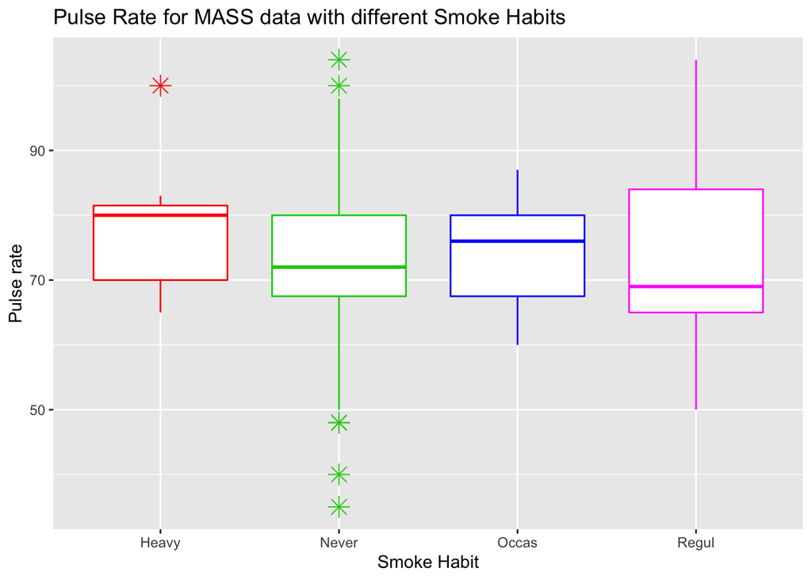

```r
loadPkg("MASS")
surveyPulseSmoke = subset(survey, Pulse>0 & !is.na(Smoke), select=c('Pulse','Smoke'))  # remove NAs
loadPkg("ggplot2")
ggplot(surveyPulseSmoke, aes(x=Smoke, y=Pulse)) +
  geom_boxplot( colour=c("#ff0000","#11cc11","#0000ff","#ff00ff"), outlier.shape=8, outlier.size=4) +
  labs(title="Pulse Rate for MASS data with different Smoke Habits", x="Smoke Habit", y = "Pulse rate")
```

```r
#plot(Pulse ~ Smoke, data=surveyPulseSmoke , main="Pulse Rate for MASS data with different Smoke Habits", col=c("#ff0000","#00ff00","#0000ff","#ff00ff") )
```

### ANOVA Test

```r
anovaRes = aov(Pulse ~ Smoke, data=surveyPulseSmoke)
# This is the standard R-notation of entering an equation, y ~ x
# We will learn and use this more as it goes on.
anovaRes  # this does not give the easy-to-read result of the aov analysis
# Use the summary function instead.
# summary(anovaRes) # better yet, use the xkabledply() function.
names(anovaRes)
```

[output not shown]

```r
xkabledply(anovaRes, title = "ANOVA result summary")
```

[output not shown]

Let us have a do-over. The above charts are good, but could be better!! The variable “Smoke” is registered as factor, but it should be ordinal. Let us add the proper order to the variable and re-do the chart.

### Better Chart

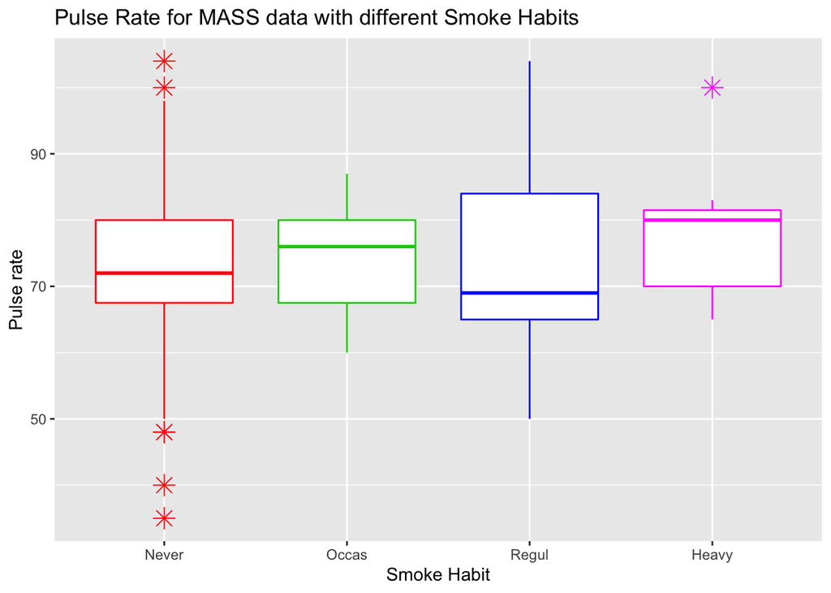

```r
# str(surveyPulseSmoke)
surveyPulseSmoke$Smoke <- factor(surveyPulseSmoke$Smoke, order=T, levels = c("Never","Occas","Regul","Heavy"))
# str(surveyPulseSmoke)
loadPkg("ggplot2")
ggplot(surveyPulseSmoke, aes(x=Smoke, y=Pulse)) +
  geom_boxplot( colour=c("#ff0000","#11cc11","#0000ff","#ff00ff"), outlier.shape=8, outlier.size=4) +
  labs(title="Pulse Rate for MASS data with different Smoke Habits", x="Smoke Habit", y = "Pulse rate")
```

```r
#plot(Pulse ~ Smoke, data=surveyPulseSmoke , main="Pulse Rate for MASS data with different Smoke Habits", col=c("#00ff00","#0000ff","#ff00ff","#ff0000") )
anovaRes = aov(Pulse ~ Smoke, data=surveyPulseSmoke)
# anovaRes    # this does not give the easy-to-read result of the aov analysis
names(anovaRes)
# summary(anovaRes)
xkabledply(anovaRes) # same exact result with or without re-ordering.
```

[output not shown]

### Post-hoc Tukey HSD (not really needed)

```r
tukeySmokeAoV <- TukeyHSD(anovaRes)
tukeySmokeAoV
```

[output not shown]

## Example 2: Agricolae

Another example (see https://rstudio-pubs-static.s3.amazonaws.com/181709_eec7a5bc24c04b8badeb297c4807109a.html for example). The library/package agricolae might not be working with the new R version anymore. Let’s try anyways.

```r
loadPkg("agricolae")
data("PlantGrowth")
loadPkg("lemon")
```

```r
xkabledply(PlantGrowth[1:4,], title = "First four rows of dataframe: `PlantGrowth`")
```

First four rows of dataframe: `PlantGrowth`

| weight | group |
| --- | --- |
| 4.17 | ctrl |
| 5.58 | ctrl |
| 5.18 | ctrl |
| 6.11 | ctrl |

```r
# head(PlantGrowth)
# str(PlantGrowth)
```

It is a simple sample dataset recording the plant growth (weight, after a fixed number of days) under three different groups: control group, treatment 1, and treatment 2.

### Chart

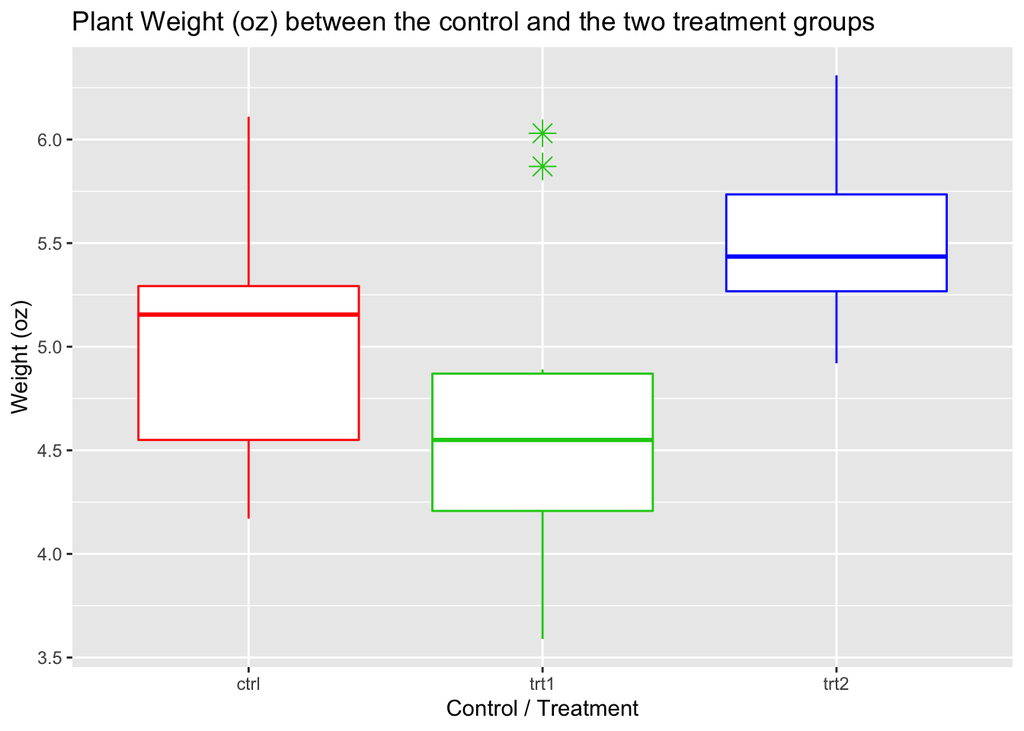

```r
loadPkg("ggplot2")
ggplot(PlantGrowth, aes(x=group, y=weight)) +
  geom_boxplot( colour=c("#ff0000","#11cc11","#0000ff"), outlier.shape=8, outlier.size=4) +
  labs(title="Plant Weight (oz) between the control and the two treatment groups", x="Control / Treatment", y = "Weight (oz)")
```

```r
# Simple plots
# plot(PlantGrowth$weight ~ PlantGrowth$group)   # OR
# plot(weight ~ group, data=PlantGrowth, main="Plant Weight (oz) between the control and the two treatment groups", col=c("#00ff00","#ff00ff","#ff0000") )
```

### ANOVA Test

Let us run the test, and look at the results:

```r
plant_aov = aov(weight ~ group, data = PlantGrowth)
# plant_aov  # this does not give the easy-to-read result of the aov analysis
# summary(plant_aov)
plantaovsummary = summary(plant_aov)
plantaovsummary
# xkabledply(plant_aov)
```

[output not shown]

### Post-hoc Tukey HSD

```r
tukeyAoV <- TukeyHSD(plant_aov)
tukeyAoV
```

[output not shown]